# Análise das taxas de suicidio do mundo entre 1990-2016

Vinicius Barbosa Polito Lopes

05/02/2021

# Projeto

## Introdução

### O que é?

“Suicídio é o ato de causar a própria morte de forma intencional.”

“O comportamento intencional de tirar a própria vida é resultado da soma de diversos fatores de origem emocional, psíquica, social e cultural. O indivíduo busca na morte o alívio, uma forma de fugir daquilo que o deprime, que o exclui de maneira insuportável. Decepções amorosas, problemas familiares ou financeiros, depressão, transtornos de personalidade, abuso de substâncias químicas, são alguns dos fatores. Claro que nem sempre tais fatores atuam como causa direta, mas podem potencializar o risco da depressão e levar ao suicídio.”

### Problema

Segundo a OMS, a segunda principal causa de mortes entre jovens de 15-29 anos é suicidio. Só perdendo para acidentes nas estradas.

Com 800 mil mortes, o suicídio está entre as 20 principais causas de morte em todo o mundo. Mais pessoas perdem a vida para esse problema do que para doenças como malária e câncer de mama ou mesmo guerra e homicídio.

E principalmente, o suicídio é evitável, algumas medidas como restringir o acesso aos meios pelos quais a pessoa pode se matar; educar a mídia sobre denúncia responsável de suicídio; implementar programas entre os jovens para desenvolver habilidades que os permitam lidar com o estresse, são algumas formas de evitar esse acontecimento.

### Abordagem

Diante deste problema, este trabalho irá apresentar a evolução das taxas de suicidio no mundo, apresentando quais grupos são mais suscetíveis a cometer esse ato. Além de fazer uma relação com indicadores socioeconômicos como o IDH e o PIB. Dessa forma, será possivel planejar soluções para esse problema dando maior ênfase aos grupos mais afetados.

### Potenciais usuários

Este trabalho servirá como parâmetro para médicos e educadores. Ele será útil mostrar quais segmentos são mais afetados pelo suicidio, podendo ajudar na prevenção desse problema, logo que eles terão estatisticas de grupos mais afetados.

## Pacotes Requeridos

| Pacote | Descrição |
| --- | --- |
| library(stringr) | Manipulação de strings e expressões regulares |
| library(dplyr) | Manipulação avançada de dados |
| library(tidyr) | Limpeza de dados |
| library(knitr) | Geração de tabelas no R Markdown |
| library(rmarkdown) | Geração de tabelas no R Markdown |
| library(DT) | Visualização de dados em tabelas |

## Preparação dos dados

### Fonte dos dados

Os dados para a realização desse trabalho foram obtidos por meio da plataforma Kaggle. Estes dados podem ser encontrados no seguinte link: [Suicide Rates Overview 1985 to 2016 | Kaggle](https://www.kaggle.com/russellyates88/suicide-rates-overview-1985-to-2016). O link sobre [Human development index (HDI)](http://hdr.undp.org/en/indicators/137506) também pode ser encontrado na página do [Suicide Rates Overview 1985 to 2016 | Kaggle](https://www.kaggle.com/russellyates88/suicide-rates-overview-1985-to-2016) como referência, mas para destacar sua utilização nesse projeto, também partilhando sua fonte aqui.

### Explicação sobre os dados

#### Suicide Rates

Esse conjunto conta com informações sobre suicidio e questões socioeconômicos em diferentes paises durante os anos de 1985-2016.

```r
suicideTable <- read.csv("master.csv",header = T,strip.white = T,na.strings = "",stringsAsFactors = T)
paged_table(suicideTable[1:5,])
```

|  | ï..country | year | sex | age | suicides_no | population | suicides.100k.pop | country.year | HDI.for.year | gdp_for_year.... | gdp_per_capita.... | generation |
| --- | --- | --- | --- | --- | --- | --- | --- | --- | --- | --- | --- | --- |
| 1 | Albania | 1987 | male | 15-24 years | 21 | 312900 | 6.71 | Albania1987 | NA | 2,156,624,900 | 796 | Generation X |
| 2 | Albania | 1987 | male | 35-54 years | 16 | 308000 | 5.19 | Albania1987 | NA | 2,156,624,900 | 796 | Silent |
| 3 | Albania | 1987 | female | 15-24 years | 14 | 289700 | 4.83 | Albania1987 | NA | 2,156,624,900 | 796 | Generation X |
| 4 | Albania | 1987 | male | 75+ years | 1 | 21800 | 4.59 | Albania1987 | NA | 2,156,624,900 | 796 | G.I. Generation |
| 5 | Albania | 1987 | male | 25-34 years | 9 | 274300 | 3.28 | Albania1987 | NA | 2,156,624,900 | 796 | Boomers |

#### IDH

Esse é o conjunto de informações do IDH de diferentes paises durante 1990-2019, vale ressaltar que o conjunto de Suicide rates contém uma coluna de IDH com alguns valores incompletos, logo esse dataset é para completar as colunas faltantes.

```r
IDH <- read.table("Human Development Index (HDI).csv",header = T,strip.white = T, sep = ",",
           dec = ".", na.strings = "",skip = 5)

paged_table(IDH[1:5,])
```

|  | HDI.Rank | Country | X1990 | X | X1991 | X.1 | X1992 | X.2 | X1993 | X.3 | X1994 | X.4 | X1995 | X.5 | X1996 | X.6 | X1997 | X.7 | X1998 | X.8 | X1999 | X.9 | X2000 | X.10 | X2001 | X.11 | X2002 | X.12 | X2003 | … |
| --- | --- | --- | --- | --- | --- | --- | --- | --- | --- | --- | --- | --- | --- | --- | --- | --- | --- | --- | --- | --- | --- | --- | --- | --- | --- | --- | --- | --- | --- | --- |
| 1 | 169 | Afghanistan | 0.302 | NA | 0.307 | NA | 0.316 | NA | 0.312 | NA | 0.307 | NA | 0.331 | NA | 0.335 | NA | 0.339 | NA | 0.344 | NA | 0.348 | NA | 0.350 | NA | 0.353 | NA | 0.384 | NA | 0.393 | … |
| 2 | 69 | Albania | 0.650 | NA | 0.631 | NA | 0.615 | NA | 0.618 | NA | 0.624 | NA | 0.637 | NA | 0.646 | NA | 0.645 | NA | 0.655 | NA | 0.665 | NA | 0.671 | NA | 0.678 | NA | 0.684 | NA | 0.691 | … |
| 3 | 91 | Algeria | 0.572 | NA | 0.576 | NA | 0.582 | NA | 0.586 | NA | 0.590 | NA | 0.595 | NA | 0.602 | NA | 0.611 | NA | 0.621 | NA | 0.629 | NA | 0.637 | NA | 0.647 | NA | 0.657 | NA | 0.667 | … |
| 4 | 36 | Andorra | .. | NA | .. | NA | .. | NA | .. | NA | .. | NA | .. | NA | .. | NA | .. | NA | .. | NA | .. | NA | 0.813 | NA | 0.815 | NA | 0.820 | NA | 0.827 | … |
| 5 | 148 | Angola | .. | NA | .. | NA | .. | NA | .. | NA | .. | NA | .. | NA | .. | NA | .. | NA | .. | NA | 0.391 | NA | 0.400 | NA | 0.410 | NA | 0.426 | NA | 0.435 | … |

### Limpeza dos Dados

Uma vez importados os dados, foi realizada uma limpeza em cada um dos datasets, antes de sua junção.

#### Suicide Rates

Nesse conjunto de dados, foi retirado algumas colunas para junção com a tabela HDI posteriormente. Além disso, só foram pegos os valores dos anos 1990 até 2016, logo que o dataset HDI da UNITED NATIONS DEVELOPMENT PROGRAMME(UNDP) não tinha informações dos anos de 1985-1989.

```r
#Tira coluna HDI com valores desatualizados
suicideTableClean <- suicideTable[,-c(1,9)]

#Remove valores anteriores de 1990
suicideTableClean <- suicideTableClean[which(suicideTableClean$year >= 1990),]
```

#### IDH

Nesse conjunto de dados, foi retirado um conjunto de colunas em branco, também foram alterados os nomes de algumas colunas. Foram retirados alguns espaços em brancos em certas variaveis. Por fim, a estrutura do dataset foi alterada para se encaixar melhor quando for alocado com o dataset de Suicide Rates.

```r
#Dropei colunas inuteis
odd_indexes<-seq(5,61,2)
IDHClean <- IDH[,c(1:3,odd_indexes)]

#Tirei espaços em brancos da variaveis de Country
IDHClean$Country <-sub(" ", "", IDHClean$Country)

#Ajeitei o nome das colunas de IDH
names(IDHClean)[3:32]<-sub(".", "", names(IDHClean)[3:32])

#Retirei as colunas dos anos de 2017-2019
IDHClean <- IDHClean[,1:29]

#Alterei estrutura do dataset
IDHClean <- IDHClean %>% gather(key="year", value = "HDI", -c(Country, HDI.Rank))

#Criei nova coluna para merge com suicideRates
IDHClean<-mutate(IDHClean, country.year= (paste(Country,year,sep="")))

#Tirei coluna year
IDHClean<- IDHClean[,-3]
```

### Conjunto de Dados Finalizado

```r
df <- merge(x=suicideTableClean,y=IDHClean, by= "country.year")
dataset <- df %>% select(Country,year,sex,age,suicides_no,population,suicides.100k.pop,HDI.Rank,HDI,country.year,gdp_for_year....,gdp_per_capita....,generation)

paged_table(dataset[1:30,])
```

|  | Country | year | sex | age | suicides_no | population | suicides.100k.pop | HDI.Rank | HDI | country.year | gdp_for_year.... | gdp_per_capita.... | generation |
| --- | --- | --- | --- | --- | --- | --- | --- | --- | --- | --- | --- | --- | --- |
| 1 | Albania | 1992 | female | 75+ years | 0 | 38700 | 0.00 | 69 | 0.615 | Albania1992 | 709,452,584 | 251 | G.I. Generation |
| 2 | Albania | 1992 | male | 5-14 years | 0 | 362900 | 0.00 | 69 | 0.615 | Albania1992 | 709,452,584 | 251 | Millenials |
| 3 | Albania | 1992 | female | 5-14 years | 0 | 336700 | 0.00 | 69 | 0.615 | Albania1992 | 709,452,584 | 251 | Millenials |
| 4 | Albania | 1992 | male | 35-54 years | 12 | 343800 | 3.49 | 69 | 0.615 | Albania1992 | 709,452,584 | 251 | Boomers |
| 5 | Albania | 1992 | female | 35-54 years | 2 | 323100 | 0.62 | 69 | 0.615 | Albania1992 | 709,452,584 | 251 | Boomers |
| 6 | Albania | 1992 | female | 55-74 years | 1 | 164900 | 0.61 | 69 | 0.615 | Albania1992 | 709,452,584 | 251 | Silent |
| 7 | Albania | 1992 | male | 75+ years | 0 | 23900 | 0.00 | 69 | 0.615 | Albania1992 | 709,452,584 | 251 | G.I. Generation |
| 8 | Albania | 1992 | female | 15-24 years | 7 | 292400 | 2.39 | 69 | 0.615 | Albania1992 | 709,452,584 | 251 | Generation X |
| 9 | Albania | 1992 | female | 25-34 years | 4 | 267400 | 1.50 | 69 | 0.615 | Albania1992 | 709,452,584 | 251 | Boomers |
| 10 | Albania | 1992 | male | 15-24 years | 9 | 263700 | 3.41 | 69 | 0.615 | Albania1992 | 709,452,584 | 251 | Generation X |

[output cut: 20 more lines]

### Dicionário dos Dados

| Coluna | Tipo | Descrição |
| --- | --- | --- |
| Country | Character | Pais |
| year | Integer | Ano |
| sex | Factor | Gênero |
| age | Factor | Faixa de idade de grupo específico |
| suicides_no | Integer | Número de Suicidios |
| population | Integer | Tamanho da população no ano |
| suicides.100k.pop | Numeric | Média de suicidios a cada 100mil pessoas |
| HDI.Rank | Integer | Ranqueamento em relação a outros paises |
| HDI | Character | IDH atual |
| gdp_for_year…. | Factor | PIB por ano |
| gdp_per_capita…. | Integer | PIB por individuo |
| generation | Factor | Geração |

## Análise exploratória dos dados

Para facilitação na observação dos dados, este tópico foi dividido em duas partes. A primeira parte é a análise quantitativa, enquanto a segunda é a análise correlativa Vale ressaltar que todos os dados não especificados são referentes a acontecimentos do mundo inteiro durante os anos de 1990-2016.

### Análise Quantitativa

Essas são análises mais diretas que podem ser obtidas diretamente do dataset com poucas alterações.

#### Faixa etária / Gerações

Nessa tabela, é possivel ver os diferentes tipos de faixa de idade encontrados no dataset e também ver as diferentes gerações. Uma informação que vale ressaltar é que devido os dados serem de diferentes periodos de tempo, algumas faixas de idade não correspondem necessariamente a apenas uma geração especifica, logo não é possivel dizer que uma faixa de etária é referente a uma geração especifica.

```r
age<-dataset

age$age<- factor(dataset$age, levels = c("5-14 years","15-24 years", "25-34 years", "35-54 years","55-74 years","75+ years"))
age$generation<- factor(dataset$age, levels = c("Generation Z","Millenials","Generation X","Boomers","Silent","G.I. Generation"))

ageset <- data.frame(levels(age$age),levels(age$generation))

kable(ageset,col.names = c("Idades","Geração"))
```

| Idades | Geração |
| --- | --- |
| 5-14 years | Generation Z |
| 15-24 years | Millenials |
| 25-34 years | Generation X |
| 35-54 years | Boomers |
| 55-74 years | Silent |
| 75+ years | G.I. Generation |

#### Paises

Essa tabela mostra de quais paises os dados foram utilizados. Vale ressaltar que o número de paises encontrados nesse dataset é 93.

```r
country<- as.factor(dataset$Country)

country<- as.character(levels(country))

country<- data.frame(country[1:15],country[16:30],country[31:45],country[46:60],country[61:75],country[76:90],country[91:93])

kable(country,col.names = c("","","","Paises","","",""))
```

|  |  |  | Paises |  |  |  |
| --- | --- | --- | --- | --- | --- | --- |
| Albania | Bulgaria | France | Kiribati | Norway | Slovakia | United States |
| Antigua and Barbuda | Cabo Verde | Georgia | Kuwait | Oman | Slovenia | Uruguay |
| Argentina | Canada | Germany | Kyrgyzstan | Panama | South Africa | Uzbekistan |
| Armenia | Chile | Greece | Latvia | Paraguay | Spain | United States |
| Australia | Colombia | Grenada | Lithuania | Philippines | Sri Lanka | Uruguay |
| Austria | Costa Rica | Guatemala | Luxembourg | Poland | Suriname | Uzbekistan |
| Azerbaijan | Croatia | Guyana | Maldives | Portugal | Sweden | United States |
| Bahamas | Cuba | Hungary | Malta | Qatar | Switzerland | Uruguay |
| Bahrain | Cyprus | Iceland | Mauritius | Romania | Thailand | Uzbekistan |
| Barbados | Denmark | Ireland | Mexico | Russian Federation | Trinidad and Tobago | United States |
| Belarus | Ecuador | Israel | Mongolia | Saint Kitts and Nevis | Turkey | Uruguay |
| Belgium | El Salvador | Italy | Montenegro | Saint Lucia | Turkmenistan | Uzbekistan |
| Belize | Estonia | Jamaica | Netherlands | Serbia | Ukraine | United States |
| Bosnia and Herzegovina | Fiji | Japan | New Zealand | Seychelles | United Arab Emirates | Uruguay |
| Brazil | Finland | Kazakhstan | Nicaragua | Singapore | United Kingdom | Uzbekistan |

### Análise Correlativa

#### Faixa etária

O seguinte gráfico mostra quais grupos de faixa etária cometeram suicidios no mundo durante 1990-2016. Isso pode nos mostrar qual fase da vida somos mais suscetíveis a cometer suicidio.

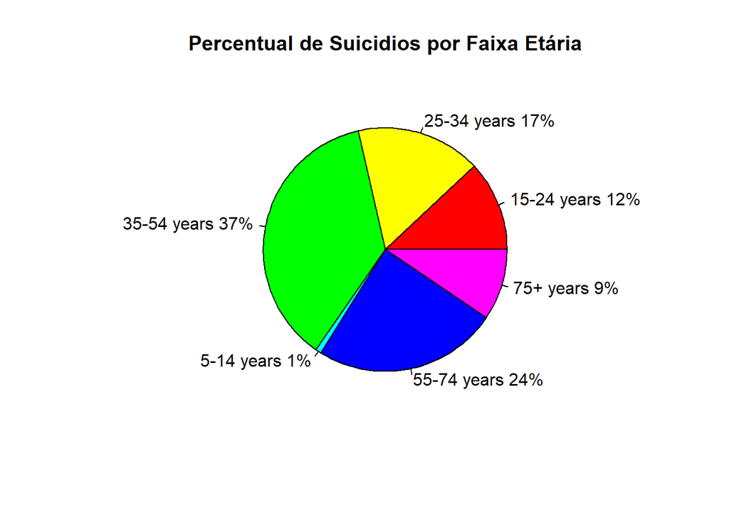

```r
group <- group_by(dataset,age)

df_aux<-summarise(group, mean(suicides_no))

pct<- round((df_aux$`mean(suicides_no)`)/(sum(df_aux$`mean(suicides_no)`))*100)

lbls<-paste(df_aux$age, pct)

lbls<-paste(lbls,"%",sep = "")

pie(df_aux$`mean(suicides_no)`,labels = lbls,main ="Percentual de Suicidios por Faixa Etária",col = rainbow(6))
```

#### Gênero

O seguinte gráfico mostra a divisão de suicidios cometidos por gênero no mundo durante 1990-2016. Isso pode nos mostrar qual gênero é mais predisposto a cometer suicidio.

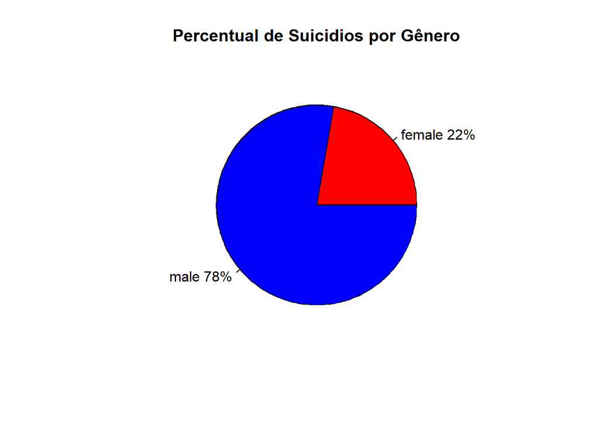

```r
group <- group_by(dataset,sex)

df_aux<-summarise(group, mean(suicides_no))

pct<- round((df_aux$`mean(suicides_no)`)/(sum(df_aux$`mean(suicides_no)`))*100)

lbls<-paste(df_aux$sex, pct)

lbls<-paste(lbls,"%",sep = "")

pie(df_aux$`mean(suicides_no)`,labels = lbls,main ="Percentual de Suicidios por Gênero",col = c("Red","Blue"))
```

#### Nações

O seguinte gráfico mostra quais nações foram mais relevantes em relação a quantidade de suicidios nos anos de 1990-2016. O trecho “Paises restantes” faz refêrencia a todos os demais paises juntos, logo que se todos fossem plotados no gráfico, ficaria inviável de serem apresentados pela quantidade de paises encontrados no dataset. Essa análise pode nos mostrar quais paises são mais propensos a ter pessoas cometendo suicidio.

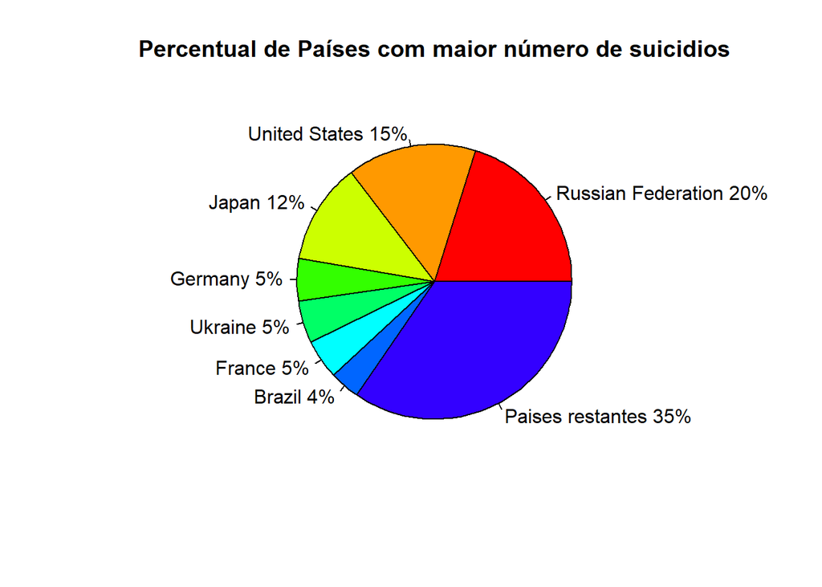

```r
group <- group_by(dataset,Country)

df_aux<-summarise(group, sum(suicides_no))

all<-arrange(df_aux,desc(`sum(suicides_no)`))
top<-all[1:7,]
rest<-all[-c(1:7),]
rest.Suicide.number <-sum(rest$`sum(suicides_no)`)

vet<-c(top$`sum(suicides_no)`,rest.Suicide.number )

pct<- round((vet)/(sum(vet))*100)

lbls<-paste(c(top$Country,"Paises restantes"), pct)

lbls<-paste(lbls,"%",sep = "")

pie(vet,main ="Percentual de Países com maior número de suicidios",labels = lbls,col = rainbow(10) )
```

#### Tempo

O seguinte gráfico mostra a evolução do número de suicidios no globo por ano. Dessa forma é possivel ver se as medidas utilizadas durante o periodo anual tiveram impacto para a redução do número de suicidios.

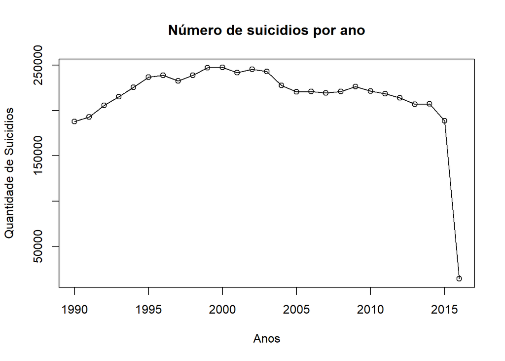

```r
group <- group_by(dataset,year)

df_aux<-summarise(group, sum(suicides_no))

plot( df_aux$year,df_aux$`sum(suicides_no)`,type = "o",main = "Número de suicidios por ano",xlab = "Anos",ylab = "Quantidade de Suicidios")
```

Aqui podemos ver a evolução do número de suicidios por ano divididos por faixa etária.

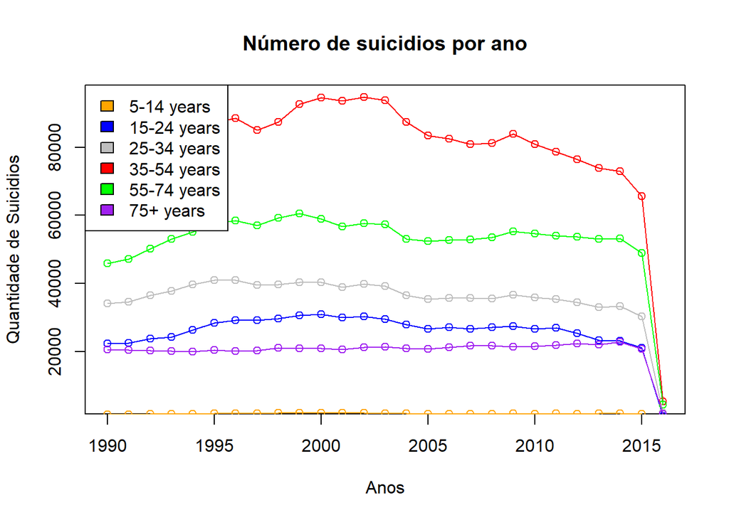

```r
g1 <- filter(dataset,age=="5-14 years")

group1 <- group_by(g1,year)

df_aux1<-summarise(group1, sum(suicides_no))
#--
g2 <- filter(dataset,age=="15-24 years")

group2 <- group_by(g2,year)

df_aux2<-summarise(group2, sum(suicides_no))
#--
g3 <- filter(dataset,age=="25-34 years")

group3 <- group_by(g3,year)

df_aux3<-summarise(group3, sum(suicides_no))
#--
g4 <- filter(dataset,age=="35-54 years")

group4 <- group_by(g4,year)

df_aux4<-summarise(group4, sum(suicides_no))
#--
g5 <- filter(dataset,age=="55-74 years")

group5 <- group_by(g5,year)

df_aux5<-summarise(group5, sum(suicides_no))
#--
g6 <- filter(dataset,age=="75+ years")

group6 <- group_by(g6,year)

df_aux6<-summarise(group6, sum(suicides_no))
#--

plot( df_aux4$year,df_aux4$`sum(suicides_no)`,type = "o",col="red",main = "Número de suicidios por ano",xlab = "Anos",ylab = "Quantidade de Suicidios")

lines(df_aux2$year,df_aux2$`sum(suicides_no)`,type = "o",col="blue")
lines(df_aux1$year,df_aux1$`sum(suicides_no)`,type = "o",col="orange")
lines(df_aux3$year,df_aux3$`sum(suicides_no)`,type = "o",col="grey")
lines(df_aux5$year,df_aux5$`sum(suicides_no)`,type = "o",col="green")
lines(df_aux6$year,df_aux6$`sum(suicides_no)`,type = "o",col="purple")

legend("topleft",fil = c("orange","blue","grey","red","green","purple"),legend = c("5-14 years","15-24 years", "25-34 years", "35-54 years","55-74 years","75+ years"))
```

#### IDH

Aqui dividi os paises em 4 grupos diferentes: Low IDH Rate, paises com IDH entre 0.350-0.554; Medium IDH Rate, paises com IDH entre 0.555-0.699; High IDH Rate, paises com IDH entre 0.700-0.799; Very High IDH Rate, paises com IDH entre 0.800-1

Então fiz a comparação do número de mortes com o PIB médio, dessa forma mostrando a predisposição das pessoas ao ato do suicidio, em relação ao PIB por pessoa.

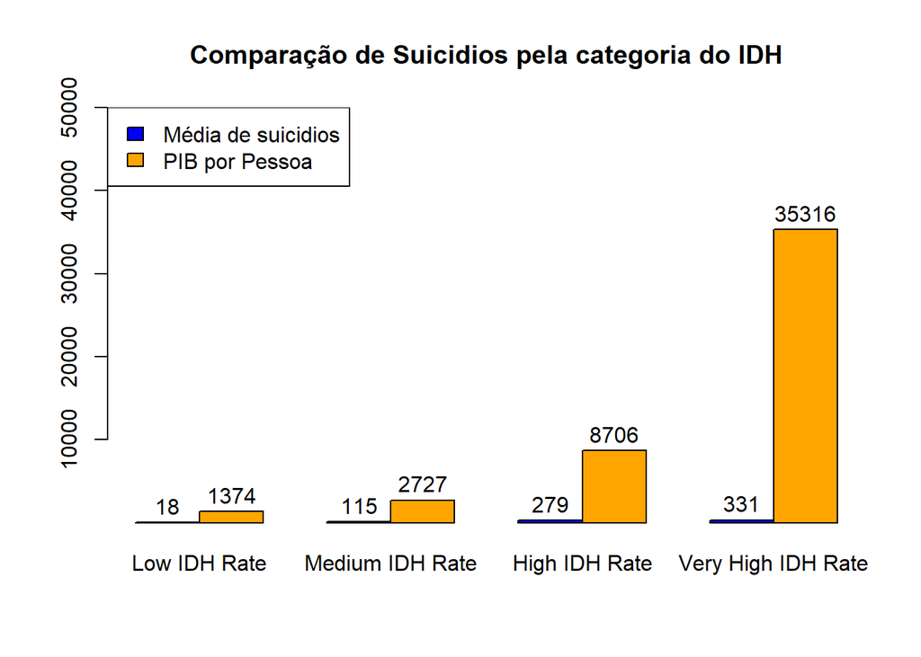

```r
countryNA <- filter(dataset, HDI == "..")
countryLow <- filter(dataset, HDI > 0.350 & HDI < 0.554)
countryMedium <- filter(dataset, HDI > 0.555 & HDI < 0.699 )
countryHigh <- filter(dataset, HDI > 0.700 & HDI < 0.799)
countryVeryHigh <- filter(dataset, HDI > 0.800  & HDI < 1)

#pib/capita,idh,suicide

value <- round(c(mean(countryLow$suicides_no),mean(countryMedium$suicides_no),
           mean(countryHigh$suicides_no),mean(countryVeryHigh$suicides_no),
           mean(countryLow$gdp_per_capita....),mean(countryMedium$gdp_per_capita....),
           mean(countryHigh$gdp_per_capita....),mean(countryVeryHigh$gdp_per_capita....)))

value <- matrix(value, nrow = 2 , ncol = 4, byrow = T)

plot<-barplot(value,main="Comparação de Suicidios pela categoria do IDH",names.arg = c("Low IDH Rate","Medium IDH Rate","High IDH Rate","Very High IDH Rate"),col= c("Blue","Orange"),beside = T,ylim = c(1,50000))

text(plot,value +2000, label = as.character(value))

legend("topleft",fil = c("Blue","Orange"),legend = c("Média de suicidios","PIB por Pessoa"))
```

#### Faixa Etária/Gênero

Nesse gráfico, mostro quais grupos e faixa etária tem maior propensão ao ato de suicidio de forma mais direta.

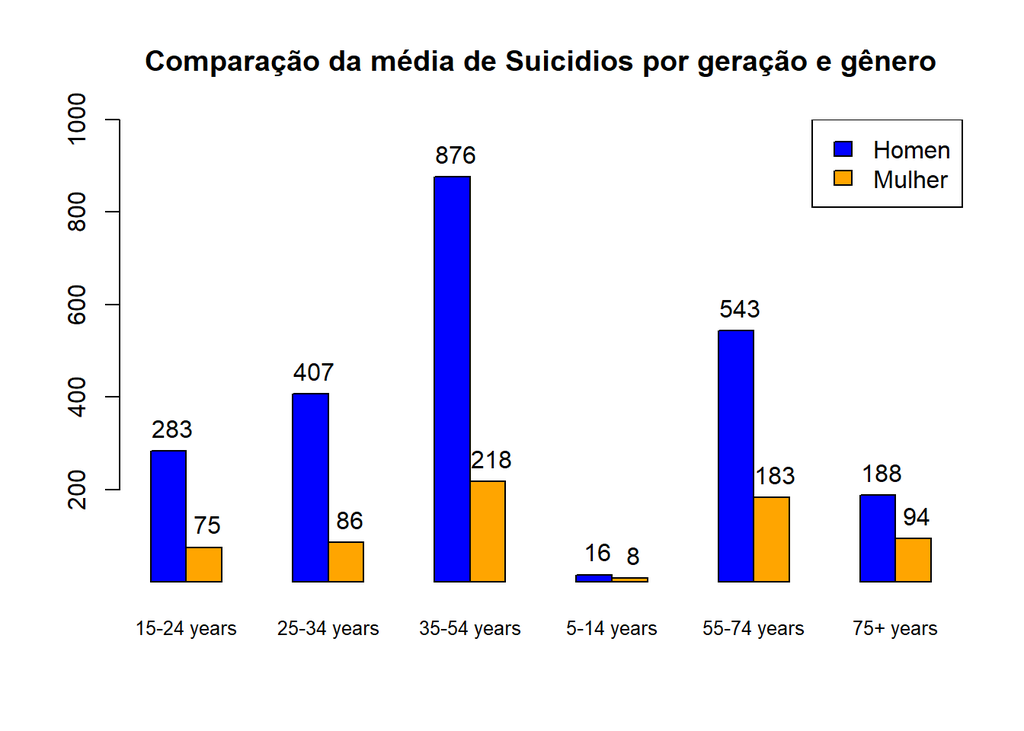

```r
man<- filter(dataset,sex=="male")
woman<-filter(dataset,sex=="female")

group <- group_by(man, age)

df_man<-summarise(group, mean(suicides_no))

group <- group_by(woman, age)

df_woman<-summarise(group, mean(suicides_no))

df_man$`mean(suicides_no)` <- round(df_man$`mean(suicides_no)`)

df_woman$`mean(suicides_no)` <- round(df_woman$`mean(suicides_no)`)

value <- c(df_man$`mean(suicides_no)`,df_woman$`mean(suicides_no)`)

value <- matrix(value, nrow = 2 , ncol = 6, byrow = T)

plot<-barplot(value,main="Comparação da média de Suicidios por geração e gênero",space = c(0,2),names.arg = df_woman$age,col= c("Blue","Orange"),beside = T,ylim = c(1,1000),cex.names=0.8)

text(plot+0.1,value+50, label = as.character(value))

legend("topright",fil = c("Blue","Orange"),legend = c("Homen","Mulher"))
```

## Conclusões

Este trabalho apresentou uma análise técnica dos dados de suicidio referentes a 93 paises durante o periodo de 1990-2016. O estudo permitiu um melhor entendimento da mudança temporal do suicidio durante esse intervalo. Por meio da Análise Correlativa, foi possivel aprender qual gênero e faixa etária tem maior tendência a cometer suicidio. Além de averiguar que fatores socioeconômicos tem uma ligação indireta, logo que os paises com maior PIB e IDH tiveram maior indice de suicidos que outros com menores indicadores.

Estes resultados são importantes para médicos e educadores identificarem possiveis individuos que precisam de ajuda, de forma que não considerem suicidio como uma opção. Vale ressaltar que os dados são limitados apenas a indicadores como gênero,idade e outros valores socioeconômicos. O suicidio não acontece apenas devido a esses fatores, existem muitas outras variáveis que deveriam ser levadas em conta para identificar um individuo propenso a tal ato. Alguns pontos que poderiam melhorar essa análise, seriam informações a respeito do historico econômico e educacional do individuo, podendo traçar um perfil mais certeiro.

Como trabalhos futuros, poderiam ser utilizadas estatisticas mais recentes para averiguar a evolução do suicidio com o tempo, além da expansão do número de paises de forma que o dataset se mostre mais realista sobre a porcentagem de tragédias do mundo.

## Referências

Materiais utilizados na argumentação da importância desse dataset:

http://g1.globo.com/sp/presidente-prudente-regiao/blog/psicoblog/post/por-que-uma-pessoa-comete-suicidio.html https://revistagalileu.globo.com/Ciencia/Saude/noticia/2019/09/6-fatos-que-provam-por-que-ainda-precisamos-falar-de-suicidio.html https://apps.who.int/iris/bitstream/handle/10665/326948/WHO-MSD-MER-19.3-eng.pdf https://pt.wikipedia.org/wiki/%C3%8Dndice_de_Desenvolvimento_Humano